# Practice9

### 데이터 불러오기

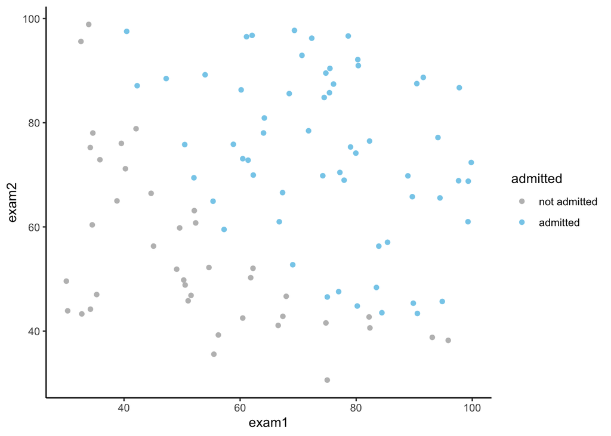

```r
path <- 'https://raw.githubusercontent.com/Paul-scpark/Data_Mining_Practicum/main/data/'
admission <- read.csv(paste0(path, 'ex2data1.txt'), header = F, col.names = c('exam1', 'exam2', 'admitted'))

admission %>%
  ggplot(aes(x = exam1, y = exam2, col = as.factor(admitted))) + geom_point() +
  scale_color_manual('admitted', values = c('grey', 'skyblue'), labels = c('not admitted', 'admitted')) +
  theme_classic()
```

exam1과 exam2의 점수를 바탕으로 대학에 합격 여부를 파악할 수 있는 주어진 데이터를 불러오도록 한다.

이를 직관적으로 확인하기 위해 X축을 exam1로, Y축을 exam2로 하고, 각 점들에 대한 label을 갖는 그래프를 그려보도록 한다.

### Logistic Regression 적용하기

```r
## Initial setting
theta_vector <- c(0, 0, 0)

feature.df <- admission %>%
  mutate(bias = 1) %>%
  select(bias, exam1, exam2)

feature.df[, 2:3] <- sapply(feature.df[, 2:3], function(x){(x - mean(x)) / sd(x)}) # Normalization
labelVector <- admission$admitted

summary(feature.df)
```

```
##       bias       exam1              exam2
##  Min.   :1   Min.   :-1.82881   Min.   :-1.91676
##  1st Qu.:1   1st Qu.:-0.75674   1st Qu.:-0.97094
##  Median :1   Median : 0.07137   Median : 0.07859
##  Mean   :1   Mean   : 0.00000   Mean   : 0.00000
##  3rd Qu.:1   3rd Qu.: 0.74869   3rd Qu.: 0.70703
##  Max.   :1   Max.   : 1.75677   Max.   : 1.75686
```

```r
table(labelVector)
```

```
## labelVector
##  0  1
## 40 60
```

합격 여부를 분류할 수 있는 모델을 만들기 위해서 input 변수와 target 변수를 나눠주도록 한다.

input 변수는 exam1과 exam2와 함께 1의 값을 갖는 bias를 추가하여 feature.df를 만들어준다.

그리고 이 데이터의 경우에는 scale의 범위 차이가 있어서 이를 좁히기 위해 정규화를 수행해준다.

최종적으로 feature.df의 summary를 통해서 각 변수들의 scale을 확인하고, target 변수의 개수 분포를 확인한다.

```r
## Hypothesis and Cost function
sigmoid <- function(x){1 / (1 + exp(-x))}
h <- function(x, theta_vector){sigmoid(theta_vector %*% x)}

costFunction <- function(theta_vector){
  hx <- apply(feature.df, 1, function(x){h(x, theta_vector)})
  costV <- labelVector * log(hx) + (1 - labelVector) * log(1 - hx)
  - mean(costV)
}

costFunction(theta_vector)
```

```
## [1] 0.6931472
```

다음으로는 Cost를 줄여나가는 학습을 진행할 수 있도록 Hypothesis와 Cost 함수들을 정의해주도록 한다.

Logistic Regression의 Hypothesis를 정의하기 위해 먼저 시그모이드를 정의해주도록 한다.

그 후에는 theta_vector를 transpose 한 것과 x를 곱한 것에 시그모이드 함수를 취하여 Hypothesis를 정의한다.

한편, Cost 함수는 -y * log(h(x)) - (1-y) * log(1 - h(x)) 이므로 이 또한 정의해주도록 한다.

이를 통해 처음 theta_vector를 c(0, 0, 0)으로 정의하고, Cost 값을 계산하면 0.6931 정도가 나오는 것을 확인할 수 있다.

```r
## Gradient Descent and Find optimal theta
costDF <- data.frame(iter = 0,
                     t0 = theta_vector[1],
                     t1 = theta_vector[2],
                     t2 = theta_vector[3],
                     cost = costFunction(theta_vector))

num_iter <- 1000
m <- nrow(feature.df)
alpha <- 1

for (i in 1:num_iter){
  theta_update <- (t(as.matrix(feature.df)) %*%
                     (apply(feature.df, 1, function(x){h(x, theta_vector)}) - labelVector)) / m * alpha
  theta_vector <- theta_vector - theta_update[, 1]
  costDF <- rbind(costDF, c(i, theta_vector, costFunction(theta_vector)))
}

head(costDF)
```

```
##   iter        t0        t1        t2      cost
## 1    0 0.0000000 0.0000000 0.0000000 0.6931472
## 2    1 0.1000000 0.2798195 0.2497281 0.5604880
## 3    2 0.1757649 0.4936199 0.4408474 0.4819085
## 4    3 0.2356784 0.6628246 0.5922794 0.4317671
## 5    4 0.2853007 0.8019858 0.7169536 0.3972796
## 6    5 0.3279244 0.9200448 0.8228565 0.3721006
```

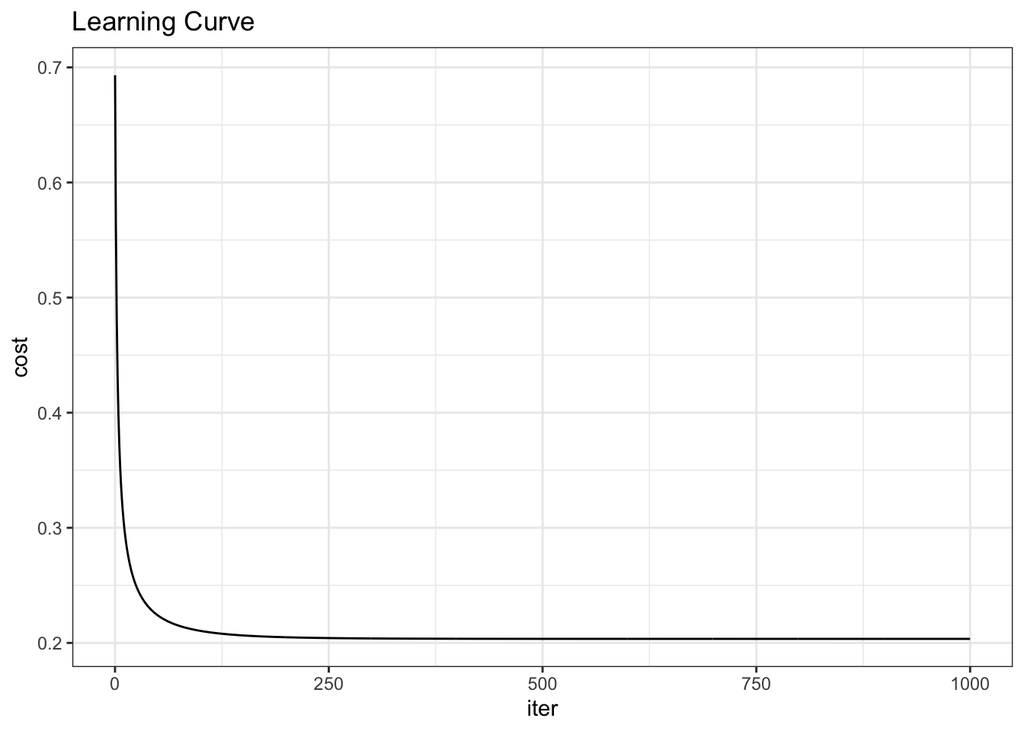

```r
## Learning Curve
costDF %>%
  ggplot(aes(x = iter, y = cost)) +
  geom_line() +
  ggtitle('Learning Curve') +
  theme_bw()
```

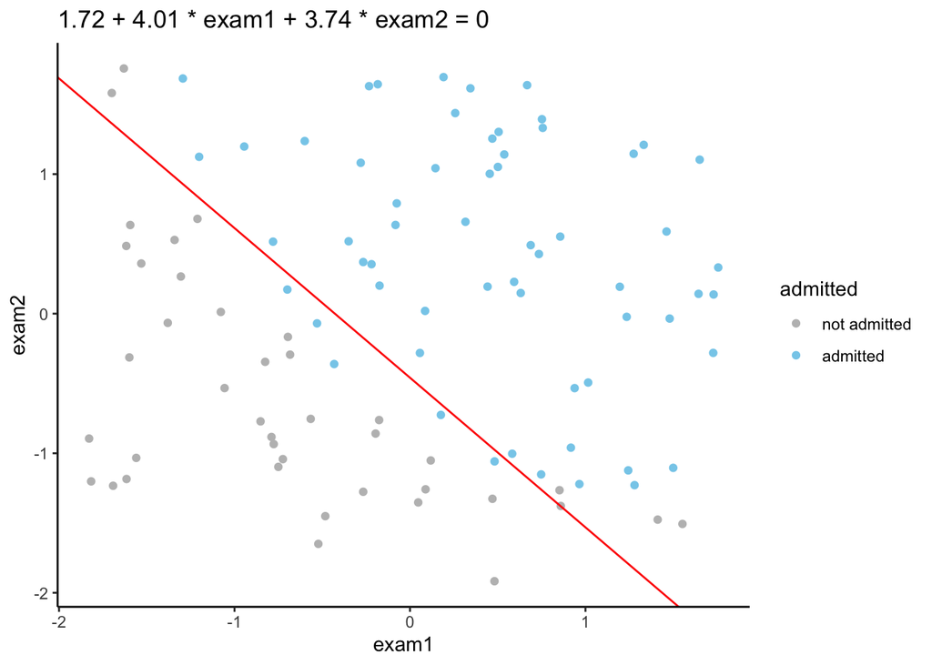

```r
## Decision Boundary
slope <- -theta_vector[2] / theta_vector[3]
bias <- -theta_vector[1] / theta_vector[3]

ggplot(feature.df, aes(x = exam1, y = exam2)) +
  geom_point(aes(col = as.factor(labelVector))) +
  geom_abline(slope = slope, intercept = bias, col = 'red') +
  scale_color_manual('admitted', values = c('grey', 'skyblue'), labels = c('not admitted', 'admitted')) +
  ggtitle(sprintf("%.2f + %.2f * exam1 + %.2f * exam2 = 0", theta_vector[1], theta_vector[2], theta_vector[3])) +
  theme_classic()
```

이제는 Cost 값의 결과들을 확인하면서 이를 줄여나갈 수 있는 theta 값을 찾으면서 계속 학습해보도록 한다.

기존 c(0, 0, 0) 이었던 theta에 대하여 alpha를 1로 설정하고, 1000번 학습을 한 결과를 확인해본다.

학습이 진행되면서 theta 값을 바꿔주기 위해 theta_update를 추가하여 기존 theta 값에 대해 그 값을 빼서 바꿔주도록 한다.

최종적으로는 costDF에 학습이 진행되면서 바뀌어가는 theta 값과 cost를 rbind 하여 값을 확인해보도록 한다.

그래프를 통해 결과를 보면 약 150번 정도 학습이 진행되었을때, 0.2 정도로 cost가 수렴하는 것을 볼 수 있다.

그리고 이를 좌표 상에 Decision Boundary와 함께 표현 위와 같은 결과가 나오는 것을 확인할 수 있다.

### 문제 1. Original scale의 Decision Boundary

하지만 위와 같은 문제 해결 방식에는 초반에 scale의 차이가 있어서 정규화를 했던 점에서 한계점이 있다.

단순 예측 과정에는 큰 무리가 없지만, Output 변수에 대해 각 (Original) Input 변수들의 영향을 확인할 수 있는 계수에 대한 해석이 어려워지는 한계가 있다.

따라서 정규화 전에 Original scale에 대하여 Decision Boundary를 설정하는 부분에 대한 고민이 필요하다.

위에서 만들어진 모델과 theta 값을 다시 original scale로 복구하여 Decision Boundary를 그려본다.

```r
mu1 <- mean(admission$exam1)
mu2 <- mean(admission$exam2)
sig1 <- sd(admission$exam1)
sig2 <- sd(admission$exam2)
```

기존에 처음 정의했던 Hypothesis는 theta1 + (theta2 x x1) + (theta3 x x2) = 0의 꼴이다.

여기서 기존 scale의 x1과 x2의 자리에 각각 정규화를 통해 (p1-mu1/sig1)과 (p2-mu2/sig2)가 들어가게 된다.

따라서 다시 Hypothesis를 정의하면, theta1 + (theta2 x (p1-mu1/sig1)) + (theta3 x (p2-mu2/sig2))로 표현할 수 있다.

이를 풀어주면 다음과 같음을 알 수 있다.

= theta1 - (theta2 x mu1 / sig1) - (theta3 x mu2 / sig2) + (theta2/sig1 * p1) + (theta3/sig2 * p2)

이와 같이 표현하여 상수항과 p1항, p2항을 각각 theta의 위치로 update 하여 theta_origin을 구해주도록 한다.

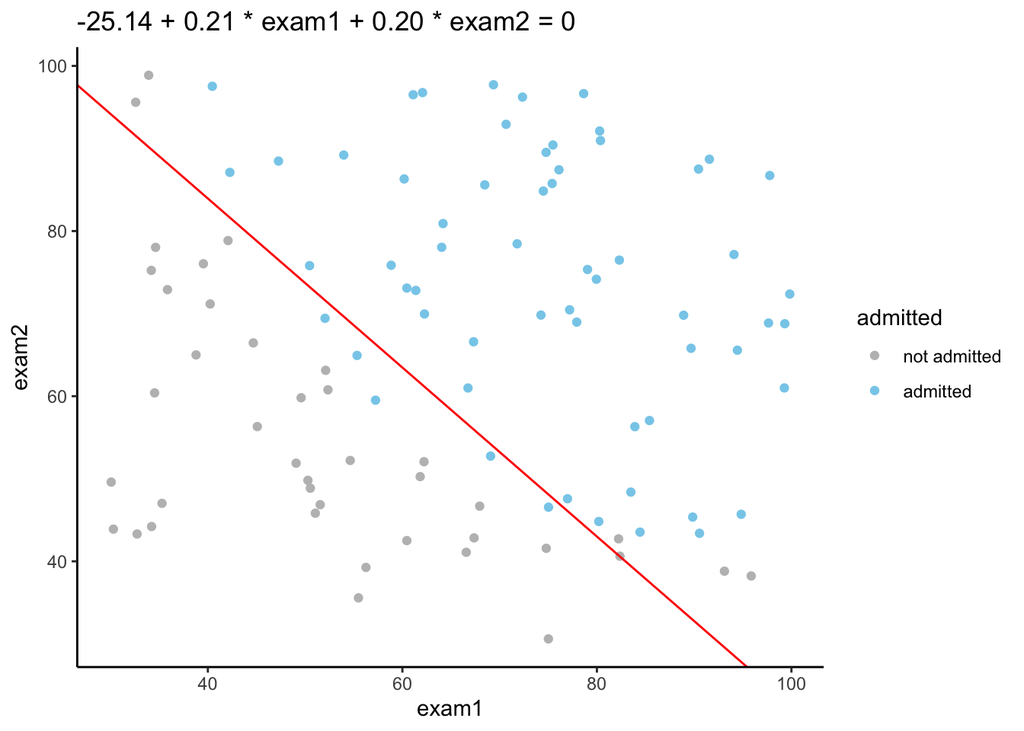

```r
theta_origin <- c(theta_vector[1] - (theta_vector[2]*mu1/sig1) - (theta_vector[3]*mu2/sig2),
                  theta_vector[2] / sig1,
                  theta_vector[3] / sig2)

slope <- -theta_origin[2] / theta_origin[3]
bias <- -theta_origin[1] / theta_origin[3]

ggplot(admission, aes(x = exam1, y = exam2)) +
  geom_point(aes(col = as.factor(labelVector))) +
  geom_abline(slope = slope, intercept = bias, col = 'red') +
  scale_color_manual('admitted', values = c('grey', 'skyblue'), labels = c('not admitted', 'admitted')) +
  ggtitle(sprintf("%.2f + %.2f * exam1 + %.2f * exam2 = 0", theta_origin[1], theta_origin[2], theta_origin[3])) +
  theme_classic()
```

이를 통해 original scale에 맞는 theta를 찾아주고, slope와 bias를 계산해준다.

그리고 이를 시각화로 표현하면 다음과 같은 결과를 확인할 수 있다.

### 문제 2. x1과 x2의 제곱한 것과 곱한 것을 새로운 Input 변수로 추가

```r
Logistic_Regression <- function(feature_df, label, num_iter, alpha){
  # (1) Hypothesis와 Cost 함수 정의
  sigmoid <- function(x){1 / (1 + exp(-x))}
  h <- function(x, theta_vector){sigmoid(theta_vector %*% x)}

  costFunction <- function(theta_vector){
    hx <- apply(feature_df, 1, function(x){h(x, theta_vector)})
    costV <- label * log(hx) + (1 - label) * log(1 - hx)
    -mean(costV, na.rm = T)
  }

  # (2) feature_df의 열 개수만큼 theta_vector를 정의해주고, Cost 함수 결과로 output_df 만들기
  theta_vector <- rep(0, ncol(feature_df))

  theta_df <- as.data.frame(t(as.data.frame(theta_vector)))
  rownames(theta_df) <- 1
  colnames(theta_df) <- str_replace(colnames(theta_df), 'V', 't')

  output_df <- data.frame(iter = 0, cost = costFunction(theta_vector), alpha = alpha, theta_df)

  # (3) Iteration 횟수만큼 학습하면서 output_df에 결과 누적시키기
  m <- nrow(feature_df)
  for (i in 1:num_iter){
    theta_update <- (t(as.matrix(feature_df)) %*%
                       (apply(feature_df, 1, function(x){h(x, theta_vector)}) - label)) / m * alpha
    theta_vector <- theta_vector - theta_update[, 1]
    output_df <- rbind(output_df, c(i, costFunction(theta_vector), alpha, theta_vector))

    # (4) Cost 함수의 감소 폭이 10e-4 보다 작으면 iteration 횟수와 상관 없이 학습 중단
    #if (output_df$cost[nrow(output_df) - 1] - output_df$cost[nrow(output_df)] <= 10e-4){break}
  }
  return (output_df)
}
```

1번 문제에서 사용했던 Logistic Regression은 변수의 개수가 3개로 고정될 때 활용될 수 있는 알고리즘이었다.

하지만 이번 문제에서는 x1과 x2 변수를 각각 제곱한 것과 두 변수를 곱한 것을 새로운 Input 변수로 활용한다.

따라서 Input 변수의 개수가 추가되기 때문에 이를 반영해줄 수 있는 알고리즘을 다시 작성했다.

정의한 Logistic_Regression 함수는 사용자로부터 feature_df를 받게 되는데, 이에 따라 자동으로 theta_vector를 생성한다.

이렇게 정의한 알고리즘을 활용하여 이번 문제를 해결해보고자 한다.

```r
feature.df <- admission[, 1:2]
feature.df[, 1:2] <- sapply(feature.df[, 1:2], function(x){(x - mean(x)) / sd(x)})
feature.df <- feature.df %>%
  mutate(bias = 1,
         exam1_square = exam1 ** 2,
         exam2_square = exam2 ** 2,
         exam1_2 = exam1 * exam2) %>%
  select(bias, exam1, exam2, exam1_square, exam2_square, exam1_2)
labelVector <- admission$admitted

summary(feature.df)
```

```
##       bias       exam1              exam2           exam1_square
##  Min.   :1   Min.   :-1.82881   Min.   :-1.91676   Min.   :0.002219
##  1st Qu.:1   1st Qu.:-0.75674   1st Qu.:-0.97094   1st Qu.:0.203976
##  Median :1   Median : 0.07137   Median : 0.07859   Median :0.564217
##  Mean   :1   Mean   : 0.00000   Mean   : 0.00000   Mean   :0.990000
##  3rd Qu.:1   3rd Qu.: 0.74869   3rd Qu.: 0.70703   3rd Qu.:1.682843
##  Max.   :1   Max.   : 1.75677   Max.   : 1.75686   Max.   :3.344557
##   exam2_square         exam1_2
##  Min.   :0.000151   Min.   :-2.86476
##  1st Qu.:0.135170   1st Qu.:-0.50340
##  Median :0.897590   Median : 0.06125
##  Mean   :0.990000   Mean   :-0.02343
##  3rd Qu.:1.522932   3rd Qu.: 0.53422
##  Max.   :3.673969   Max.   : 2.18323
```

```r
table(labelVector)
```

```
## labelVector
##  0  1
## 40 60
```

위와 동일하게 주어진 조건에 따라 bias와 3개의 변수를 새롭게 추가하고, 정규화를 시켜주도록 한다.

이를 통해 새롭게 만들었던 변수들이 잘 정규화가 되었는지 summary 함수로 확인하고, label 변수도 확인한다.

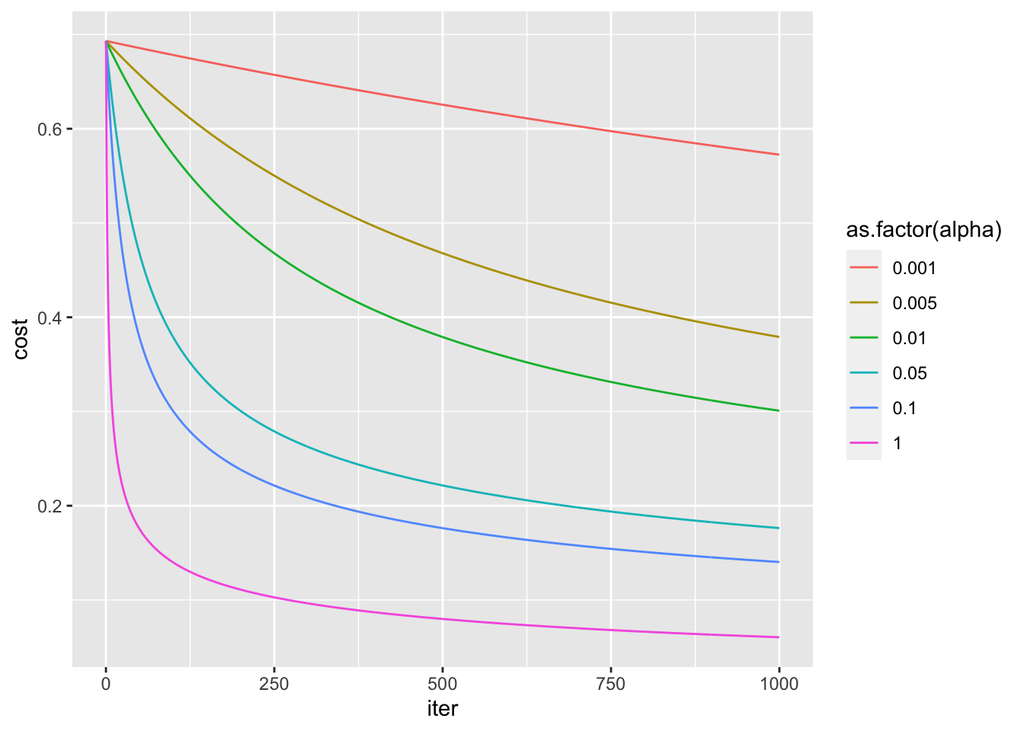

```r
alpha_vec <- c(0.001, 0.005, 0.01, 0.05, 0.1, 1)
alpha_list <- list()
for (alpha in alpha_vec){
  alpha_list[[paste0('alpha_', alpha)]] <- Logistic_Regression(feature.df, labelVector, 1000, alpha)
}

total_df <- data.frame()
for (i in alpha_list){
  total_df <- rbind(total_df, i)
}

total_df %>%
  filter(cost != Inf) %>%
  ggplot(aes(x = iter, y = cost, color = as.factor(alpha))) +
  geom_line()
```

그리고 alpha 값을 0.001부터 1까지 수정하여 각각의 학습률에 따른 cost의 변화를 확인해보도록 한다.

결과를 확인해보면, 학습률이 1일때 가장 빠르게 그리고 Cost 함수가 최솟값을 갖는 것을 확인할 수 있다.

1000번 정도 반복했을때, 0.1보다 작은 Cost 함수의 결과값을 갖는다.

따라서 이 경우에 대해서만 다시 한번 Learning curve의 추이를 그려보도록 한다.

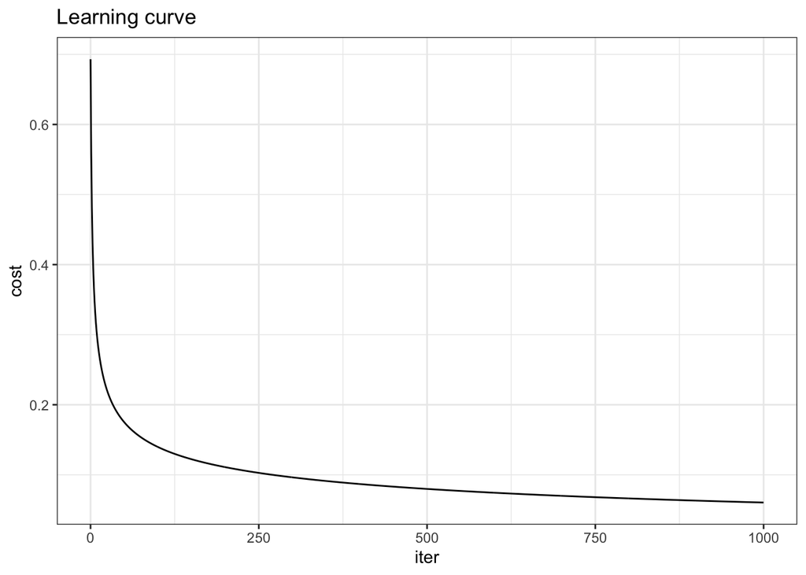

```r
total_df %>%
  filter(alpha == 1) %>%
  ggplot(aes(x = iter, y = cost)) +
  geom_line() +
  ggtitle('Learning curve') +
  theme_bw()
```

학습률이 1인 경우에 대해서만 iteration에 따른 cost 감소 추이를 그려도 위와 같은 결과를 다시 확인할 수 있다.

학습이 진행됨에 따라 계속해서 Cost가 줄어드는 것을 확인할 수 있고, 최종적으로는 0.1 보다 작은 값을 갖는다.

```r
tail(costDF, 1)
```

```
##      iter       t0       t1       t2      cost
## 1001 1000 1.716621 4.008976 3.740103 0.2034978
```

```r
total_df %>%
  filter(alpha == 1) %>%
  select(-alpha) %>% tail(1)
```

```
##       iter       cost       t1       t2       t3        t4       t5        t6
## 10015 1000 0.06045662 7.040326 6.848233 6.935626 -3.434677 -2.34361 -1.984984
```

변수를 추가하기 전과 후에 결과를 비교하면서 cost 값도 각각 확인해보고자 한다.

먼저 기존에는 1000번 학습했을 때, cost가 0.2035 정도까지 감소한 것을 확인할 수 있다.

각 변수들을 제곱하거나, 곱하는 과정들을 통해서 target 변수 예측에 설명력이 조금 더해질 수 있었던 것 같다.

### 문제 3. 문제 2에서 학습한 모델의 Decision Boundary의 그래프와 식 표현

```r
theta_df <- total_df %>%
  filter(alpha == 1) %>%
  select(-alpha) %>% tail(1)

contour_df <-
  data_frame(exam1 = rep(seq(min(feature.df$exam1), max(feature.df$exam2), length=100), times=100),
             exam2 = rep(seq(min(feature.df$exam2), max(feature.df$exam2), length=100), each=100),
             z = theta_df$t1 +
               theta_df$t2*exam1 +
               theta_df$t3*exam2 +
               theta_df$t4*exam1^2 +
               theta_df$t5*exam2^2 +
               theta_df$t6*exam1*exam2)

head(contour_df, 20)
```

```
## # A tibble: 20 × 3
##    exam1 exam2     z
##    <dbl> <dbl> <dbl>
##  1 -1.83 -1.92 -45.8
##  2 -1.79 -1.92 -45.0
##  3 -1.76 -1.92 -44.2
##  4 -1.72 -1.92 -43.4
##  5 -1.68 -1.92 -42.5
##  6 -1.65 -1.92 -41.7
##  7 -1.61 -1.92 -41.0
##  8 -1.58 -1.92 -40.2
##  9 -1.54 -1.92 -39.4
## 10 -1.50 -1.92 -38.6
## 11 -1.47 -1.92 -37.9
## 12 -1.43 -1.92 -37.1
## 13 -1.39 -1.92 -36.4
## 14 -1.36 -1.92 -35.7
## 15 -1.32 -1.92 -34.9
## 16 -1.29 -1.92 -34.2
## 17 -1.25 -1.92 -33.5
## 18 -1.21 -1.92 -32.8
## 19 -1.18 -1.92 -32.2
## 20 -1.14 -1.92 -31.5
```

이번에는 위에서 학습한 결과로 Decision Boundary를 그려보도록 한다.

이를 위해서 최종적으로 가장 cost가 낮았던 alpha가 1일때의 theta 값들을 확인해본다.

그 후에는 geom_contour 함수를 적용하기 위하여 식을 만들 때 사용되었던 exam1과 exam2 변수를 가지고 온다.

그리고 나서는 최종적으로 구했던 theta 값들을 대입하여 각각의 input 변수에 따른 결과값을 가진 z 변수를 만들어주도록 한다.

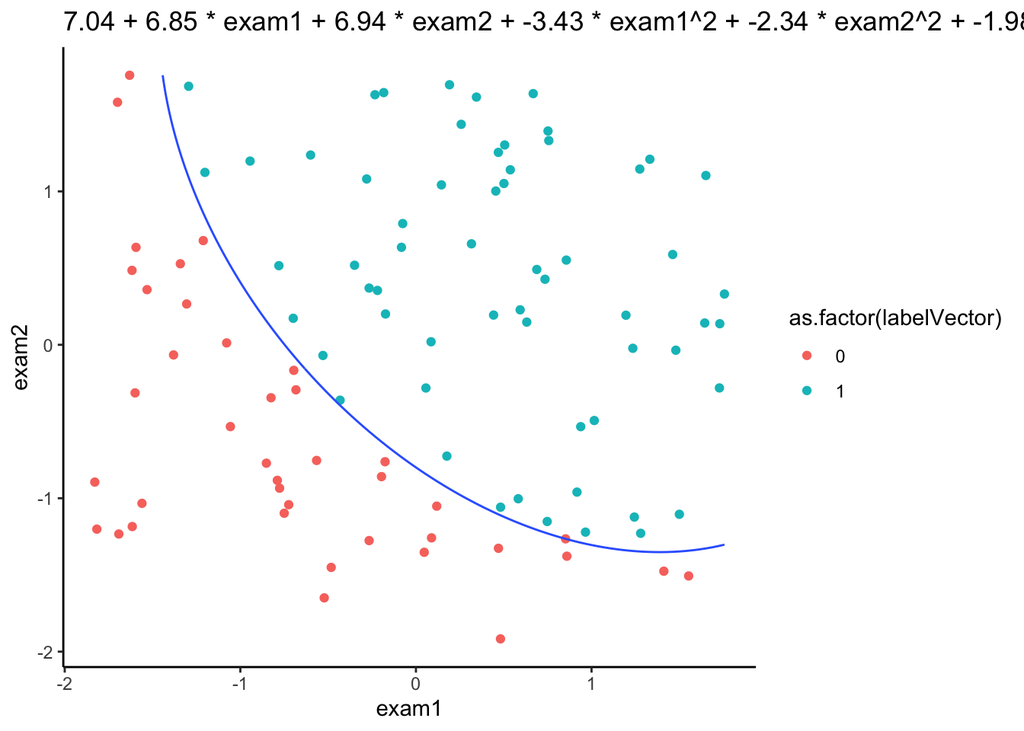

```r
ggplot(feature.df, aes(x = exam1, y = exam2)) +
  geom_point(aes(col = as.factor(labelVector))) +
  geom_contour(data = contour_df, aes(x = exam1, y = exam2, z = z), breaks = c(0)) +
  ggtitle(sprintf("%.2f + %.2f * exam1 + %.2f * exam2 + %.2f * exam1^2 + %.2f * exam2^2 + %.2f * exam1*exam2 = 0",
                  theta_df$t1, theta_df$t2, theta_df$t3, theta_df$t4, theta_df$t5, theta_df$t6)) +
  theme_classic()
```

그 후에는 이를 ggplot을 이용하여 식을 정의하고, 시각화를 표현해보도록 한다.

비선형으로 추가된 Decision Boundary를 표현하기 위하여 geom_contour 함수를 사용해주도록 한다.

2개의 input 변수인 exam1과 exam2 그리고 해당 변수들을 통해 계산된 식의 결과값 z를 활용하여 Boundary를 표현하면 위와 같음을 알 수 있다.

또한 그 식은 7.04 x (6.85 x exam1) + (6.94 x exam2) - (3.43 x exam1^2) - (2.34 x exam2^2) - (1.98 x exam1 x exam2) = 0이다.

### 문제 4. 타이타닉 데이터에 대해 분류 모델 만들어보기

```r
train <- read.csv('./train.csv')
test <- read.csv('./test.csv')
ID <- test$PassengerId

str(train)
```

```
## 'data.frame':    891 obs. of  12 variables:
##  $ PassengerId: int  1 2 3 4 5 6 7 8 9 10 ...
##  $ Survived   : int  0 1 1 1 0 0 0 0 1 1 ...
##  $ Pclass     : int  3 1 3 1 3 3 1 3 3 2 ...
##  $ Name       : chr  "Braund, Mr. Owen Harris" "Cumings, Mrs. John Bradley (Florence Briggs Thayer)" "Heikkinen, Miss. Laina" "Futrelle, Mrs. Jacques Heath (Lily May Peel)" ...
##  $ Sex        : chr  "male" "female" "female" "female" ...
##  $ Age        : num  22 38 26 35 35 NA 54 2 27 14 ...
##  $ SibSp      : int  1 1 0 1 0 0 0 3 0 1 ...
##  $ Parch      : int  0 0 0 0 0 0 0 1 2 0 ...
##  $ Ticket     : chr  "A/5 21171" "PC 17599" "STON/O2. 3101282" "113803" ...
##  $ Fare       : num  7.25 71.28 7.92 53.1 8.05 ...
##  $ Cabin      : chr  "" "C85" "" "C123" ...
##  $ Embarked   : chr  "S" "C" "S" "S" ...
```

```r
str(test)
```

```
## 'data.frame':    418 obs. of  11 variables:
##  $ PassengerId: int  892 893 894 895 896 897 898 899 900 901 ...
##  $ Pclass     : int  3 3 2 3 3 3 3 2 3 3 ...
##  $ Name       : chr  "Kelly, Mr. James" "Wilkes, Mrs. James (Ellen Needs)" "Myles, Mr. Thomas Francis" "Wirz, Mr. Albert" ...
##  $ Sex        : chr  "male" "female" "male" "male" ...
##  $ Age        : num  34.5 47 62 27 22 14 30 26 18 21 ...
##  $ SibSp      : int  0 1 0 0 1 0 0 1 0 2 ...
##  $ Parch      : int  0 0 0 0 1 0 0 1 0 0 ...
##  $ Ticket     : chr  "330911" "363272" "240276" "315154" ...
##  $ Fare       : num  7.83 7 9.69 8.66 12.29 ...
##  $ Cabin      : chr  "" "" "" "" ...
##  $ Embarked   : chr  "Q" "S" "Q" "S" ...
```

이번 문제에서는 타이타닉 데이터를 이용하여 생존자를 예측할 수 있는 분류 모델을 만들어본다.

train과 test 데이터를 불러와서 str 함수로 각각에 데이터를 확인해보도록 한다.

train 데이터는 target 변수인 ’Survived’를 포함하여 총 12개 변수가 있고, test는 11개 변수가 있다.

이에 대한 모델을 만들어보기 위해 간단히 데이터를 확인해보고, 전처리해보도록 한다.

```r
# NA 처리하기
colSums(is.na(train))
```

```
## PassengerId    Survived      Pclass        Name         Sex         Age
##           0           0           0           0           0         177
##       SibSp       Parch      Ticket        Fare       Cabin    Embarked
##           0           0           0           0           0           0
```

```r
colSums(is.na(test))
```

```
## PassengerId      Pclass        Name         Sex         Age       SibSp
##           0           0           0           0          86           0
##       Parch      Ticket        Fare       Cabin    Embarked
##           0           0           1           0           0
```

가장 먼저는 train과 test 데이터에 대하여 각 변수별로 NA의 여부를 확인해보도록 한다.

결과를 보면, train 데이터에는 Age 변수에만 177개의 NA가 있었고, test 데이터에는 Age와 Fare 변수에 NA가 있었다.

NA가 존재하는 경우에는 모델이 제대로 만들어지고, 작동되기 어렵기 때문에 처리를 해줘야 한다.

먼저 NA가 가장 많았던 Age 변수의 NA를 대체할 수 있는 방법을 고민해보도록 한다.

```r
head(train$Name)
```

```
## [1] "Braund, Mr. Owen Harris"
## [2] "Cumings, Mrs. John Bradley (Florence Briggs Thayer)"
## [3] "Heikkinen, Miss. Laina"
## [4] "Futrelle, Mrs. Jacques Heath (Lily May Peel)"
## [5] "Allen, Mr. William Henry"
## [6] "Moran, Mr. James"
```

```r
train$name_label <- gsub("^.*, (.*?)\\..*$", "\\1", train$Name)
name_age <- aggregate(Age~name_label, train, mean)
colnames(name_age) <- c('name_label', 'Age_mean')
name_age
```

```
##      name_label  Age_mean
## 1          Capt 70.000000
## 2           Col 58.000000
## 3           Don 40.000000
## 4            Dr 42.000000
## 5      Jonkheer 38.000000
## 6          Lady 48.000000
## 7         Major 48.500000
## 8        Master  4.574167
## 9          Miss 21.773973
## 10         Mlle 24.000000
## 11          Mme 24.000000
## 12           Mr 32.368090
## 13          Mrs 35.898148
## 14           Ms 28.000000
## 15          Rev 43.166667
## 16          Sir 49.000000
## 17 the Countess 33.000000
```

가장 먼저 Name 변수를 확인해보면, 영어 표현이긴 하지만 성과 이름 그리고 그 사람을 부르는 호칭이 들어가있다.

예를들면, Mr, Mrs, Miss, Master 등의 호칭을 통해서 정확하지는 않겠지만 나이를 유추해볼 수 있을 것이다.

따라서 정규표현식을 활용하여 첫번째 단어와 콤마 그리고 두번째 단어와 .으로 끝나는 부분만을 추리도록 한다.

이렇게 되면, 위에서 이야기했던 Mr, Mrs, Miss, Mrs, Mr, Mr 등의 단어들이 추출될 수 있다.

이를 name_label이라는 새로운 변수로 만들어주고, aggregate 함수를 통해서 같은 호칭 별로의 평균 나이를 구해준다.

```r
train <- train %>%
  left_join(name_age, by = 'name_label') %>%
  mutate(Age = ifelse(is.na(Age), Age_mean, Age)) %>%
  select(-name_label, -Age_mean)

colSums(is.na(train))
```

```
## PassengerId    Survived      Pclass        Name         Sex         Age
##           0           0           0           0           0           0
##       SibSp       Parch      Ticket        Fare       Cabin    Embarked
##           0           0           0           0           0           0
```

그리고 나서는 각 호칭 별로 평균 나이를 가지고 있는 name_age 데이터를 train과 join 해준다.

그 후에는 Age 값이 NA인 데이터는 평균 나이로 대체해주도록 한다. 이를 통해 train 데이터에 모든 NA가 사라진 것을 확인할 수 있다.

```r
# test 데이터에서도 NA를 모두 없애주기
test$name_label <- gsub("^.*, (.*?)\\..*$", "\\1", test$Name)

test <- test %>%
  left_join(name_age, by = 'name_label') %>%
  mutate(Age = ifelse(is.na(Age), Age_mean, Age)) %>%
  select(-name_label, -Age_mean)

test[is.na(test$Fare), ]
```

```
##     PassengerId Pclass               Name  Sex  Age SibSp Parch Ticket Fare
## 153        1044      3 Storey, Mr. Thomas male 60.5     0     0   3701   NA
##     Cabin Embarked
## 153              S
```

test 데이터에서도 똑같이 name_age를 join 하여 NA인 Age 값들을 바꿔주도록 한다.

한편, test 데이터에는 Fare(요금)에 대한 데이터 중에 하나가 NA인 것을 확인했었다. 이 또한 바꿔주기 위해서 해당 변수를 확인해보도록 한다.

결과를 보면, 60세의 Embarked(승선항, 출항지)는 S이고, Pclass(선실의 등급)는 3이다.

따라서 비슷한 나이대에서 Embarked는 S이고, Pclass는 3인 Fare의 값으로 대체해주도록 한다.

```r
train %>%
  filter(Embarked == 'S') %>%
  filter(Pclass == 3) %>%
  filter(Age >= 60)
```

```
##   PassengerId Survived Pclass                      Name    Sex Age SibSp Parch
## 1         327        0      3 Nysveen, Mr. Johan Hansen   male  61     0     0
## 2         484        1      3    Turkula, Mrs. (Hedwig) female  63     0     0
## 3         852        0      3       Svensson, Mr. Johan   male  74     0     0
##   Ticket   Fare Cabin Embarked
## 1 345364 6.2375              S
## 2   4134 9.5875              S
## 3 347060 7.7750              S
```

```r
test$Fare <- ifelse(is.na(test$Fare), 7.867, test$Fare)
colSums(is.na(test))
```

```
## PassengerId      Pclass        Name         Sex         Age       SibSp
##           0           0           0           0           0           0
##       Parch      Ticket        Fare       Cabin    Embarked
##           0           0           0           0           0
```

train 데이터에서 위의 조건을 충족하는 사람들을 확인해보면, 총 3명이 나온다.

또한 이들의 Fare는 6.2, 9.5, 7.7 달러 정도로 거의 유사한 것을 확인할 수 있다. 평균 값은 7.867이다.

따라서 이 값들의 평균으로 test 데이터에 있는 Fare의 NA 값을 대체해주도록 한다.

이를 통해 test 데이터에 대해서도 모든 변수들이 NA가 없는 것을 확인할 수 있다.

```r
colnames(train)
```

```
##  [1] "PassengerId" "Survived"    "Pclass"      "Name"        "Sex"
##  [6] "Age"         "SibSp"       "Parch"       "Ticket"      "Fare"
## [11] "Cabin"       "Embarked"
```

```r
train <- train %>%
  select(-PassengerId, -Name, -Ticket, -Cabin)

train <- train %>%
  transform(Sex_male = ifelse(Sex == 'male', 1, 0),
            Sex_female = ifelse(Sex == 'female', 1, 0),
            Embarked_S = ifelse(Embarked == 'S', 1, 0),
            Embarked_C = ifelse(Embarked == 'C', 1, 0),
            Embarked_Q = ifelse(Embarked == 'Q', 1, 0)) %>%
  select(-Sex, -Embarked) %>%
  mutate(Age = log(Age), Fare = log(Fare)) %>%
  mutate(Fare = ifelse(Fare == -Inf, 0, Fare))

summary(train)
```

```
##     Survived          Pclass           Age              SibSp
##  Min.   :0.0000   Min.   :1.000   Min.   :-0.8675   Min.   :0.000
##  1st Qu.:0.0000   1st Qu.:2.000   1st Qu.: 3.0807   1st Qu.:0.000
##  Median :0.0000   Median :3.000   Median : 3.4012   Median :0.000
##  Mean   :0.3838   Mean   :2.309   Mean   : 3.2292   Mean   :0.523
##  3rd Qu.:1.0000   3rd Qu.:3.000   3rd Qu.: 3.5807   3rd Qu.:1.000
##  Max.   :1.0000   Max.   :3.000   Max.   : 4.3820   Max.   :8.000
##      Parch             Fare          Sex_male        Sex_female
##  Min.   :0.0000   Min.   :0.000   Min.   :0.0000   Min.   :0.0000
##  1st Qu.:0.0000   1st Qu.:2.068   1st Qu.:0.0000   1st Qu.:0.0000
##  Median :0.0000   Median :2.671   Median :1.0000   Median :0.0000
##  Mean   :0.3816   Mean   :2.894   Mean   :0.6476   Mean   :0.3524
##  3rd Qu.:0.0000   3rd Qu.:3.434   3rd Qu.:1.0000   3rd Qu.:1.0000
##  Max.   :6.0000   Max.   :6.239   Max.   :1.0000   Max.   :1.0000
##    Embarked_S       Embarked_C       Embarked_Q
##  Min.   :0.0000   Min.   :0.0000   Min.   :0.00000
##  1st Qu.:0.0000   1st Qu.:0.0000   1st Qu.:0.00000
##  Median :1.0000   Median :0.0000   Median :0.00000
##  Mean   :0.7228   Mean   :0.1886   Mean   :0.08642
##  3rd Qu.:1.0000   3rd Qu.:0.0000   3rd Qu.:0.00000
##  Max.   :1.0000   Max.   :1.0000   Max.   :1.00000
```

이제는 기본적인 전처리는 모두 마무리 되었으니, 모델에 활용할 수 있는 변수들을 추려보도록 한다.

PassengerId는 사용자를 구분하기 위함이기 때문에 제거하고, Name 역시 모델의 성능에는 도움이 되지 않기 때문에 제거한다.

또한 ticket과 Cabin 역시도 해당 변수만으로는 특별한 패턴을 찾아 보기 힘들기 때문에 제거해주도록 한다.

그리고 범주형 변수의 형태를 갖는 Sex와 Embarked 변수는 Dummy coding 처리를 해주도록 한다.

마지막으로는 Age와 Fare 변수의 경우에는 scale 차이가 심하기 때문에 log를 통해서 표준화를 시켜주도록 한다.

이를 통해 최종적인 train 데이터를 구축할 수 있다.

```r
test <- test %>%
  select(-PassengerId, -Name, -Ticket, -Cabin)

test <- test %>%
  transform(Sex_male = ifelse(Sex == 'male', 1, 0),
            Sex_female = ifelse(Sex == 'female', 1, 0),
            Embarked_S = ifelse(Embarked == 'S', 1, 0),
            Embarked_C = ifelse(Embarked == 'C', 1, 0),
            Embarked_Q = ifelse(Embarked == 'Q', 1, 0)) %>%
  select(-Sex, -Embarked) %>%
  mutate(Age = log(Age), Fare = log(Fare), bias = 1) %>%
  mutate(Fare = ifelse(Fare == -Inf, 0, Fare))
```

이와 같은 전처리 과정을 test 데이터도 동일하게 수행해주도록 한다.

이렇게 최종적인 train과 test가 준비되었고, train 데이터에 대하여 Logistic Regression으로 모델을 만들어본다.

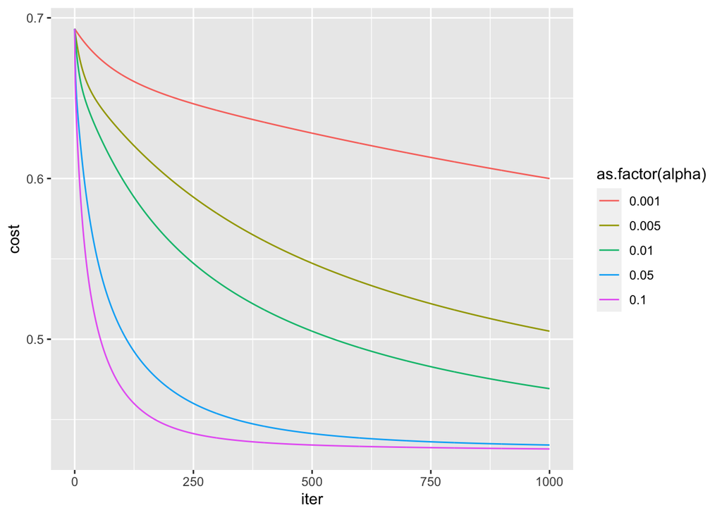

```r
feature.df <- train %>%
  mutate(bias = 1) %>%
  select(-Survived)

labelVector <- train$Survived

feature.df <- train %>%
  mutate(bias = 1) %>%
  select(-Survived)

labelVector <- train$Survived

alpha_vec <- c(0.001, 0.005, 0.01, 0.05, 0.1)
alpha_list <- list()
for (alpha in alpha_vec){
  alpha_list[[paste0('alpha_', alpha)]] <- Logistic_Regression(feature.df, labelVector, 1000, alpha)
}

total_df <- data.frame()
for (i in alpha_list){
  total_df <- rbind(total_df, i)
}

total_df %>%
  filter(cost != Inf) %>%
  ggplot(aes(x = iter, y = cost, color = as.factor(alpha))) +
  geom_line()
```

```r
total_df %>%
  filter(alpha == 0.1) %>% tail(1)
```

```
##       iter      cost alpha         t1        t2         t3         t4        t5
## 10014 1000 0.4317033   0.1 -0.3320476 -0.700146 -0.5842585 -0.3583548 0.8438647
##              t6       t7         t8        t9       t10       t11
## 10014 -1.105426 1.559754 0.01363332 0.2390168 0.1786039 0.4543287
```

모델링을 위해서 모델에 활용되는 input 변수들의 feature.df와 생존여부를 담고 있는 labelVector를 만들어준다.

그리고 나서는 위에서 정의했던 Logistic_Regression 함수를 활용하여 각 iteration에 대해 cost가 줄어드는 것을 그래프로 확인하도록 한다.

그리고 alpha 값을 0.001부터 0.1까지 조정하면서 출력되는 cost 값들을 iteration과 함께 그래프로 그려보았다.

결과를 확인하면, 가장 학습률이 큰 0.1 일때, Cost 값이 최솟값이 되고 있음을 확인할 수 있다.

해당 결과에 대하여 각 theta 값을 위와 같이 확인해볼 수 있다. 이를 활용하여 train과 test 데이터에 대하여 직접 생존자를 분류해보도록 한다.

### 문제 5. 만든 모델을 통해 train 데이터와 test 데이터의 결과 비교

```r
theta_df <- total_df %>%
  filter(alpha == 0.1) %>% tail(1)
theta_df <- theta_df[4:14]

train$pred <- ifelse(as.matrix(feature.df) %*% t(as.matrix(theta_df)) > 0, 1, 0)
accuracy(train$Survived, train$pred)
```

```
## [1] 0.8069585
```

```r
rmse(train$Survived, train$pred)
```

```
## [1] 0.4393649
```

alpha 값을 바꿔가면서 성능이 가장 좋았던 0.1 일때의 theta 값들을 가져와서 theta_df에 다시 할당해준다.

그리고 나서는 Pclass부터 bias까지 총 11개 변수를 가지고 있는 feature.df에 대하여 theta 값이 각 계수의 역할을 수행해준다.

따라서 각 메트릭스의 행과 열을 맞춰서 내적하여 각각에 대한 결과를 계산한다. 그리고 그 값이 0 보다 큰 경우에는 1로, 그렇지 않은 경우에는 0으로 할당해준다.

이를 모델을 만들었던 train 데이터에 먼저 적용하여 평가지표인 accuracy 값을 확인해보면, 약 0.807 정도의 값이 나오는 것을 확인할 수 있다.

그렇다면, 이 모델을 test 데이터에 적용한다면 어떠한 결과가 나오는지 실제 Kaggle 사이트에 결과를 올려서 점수를 확인해보도록 한다.

```r
test$Survived <- ifelse(as.matrix(test) %*% t(as.matrix(theta_df)) > 0, 1, 0)

df <- as.data.frame(cbind(PassengerId = ID, Survived = test$Survived))
colnames(df) <- c('PassengerId', 'Survived')
head(df, 10)
```

```
##    PassengerId Survived
## 1          892        0
## 2          893        0
## 3          894        0
## 4          895        0
## 5          896        1
## 6          897        0
## 7          898        1
## 8          899        0
## 9          900        1
## 10         901        0
```

```r
#write.csv(df, '/Users/paul/Desktop/gender_submission.csv', row.names = FALSE)
```

train과 동일한 방식으로 train 데이터로부터 구했던 theta 값을 활용해서 각 변수들과 내적한 값이 0 보다 큰지, 작은지를 확인한다.

그리고 PassengerId와 생존 여부를 의미하는 예측값인 Survived만 추려서 데이터를 만들어서 Kaggle에 제출하여 결과를 확인해본다.

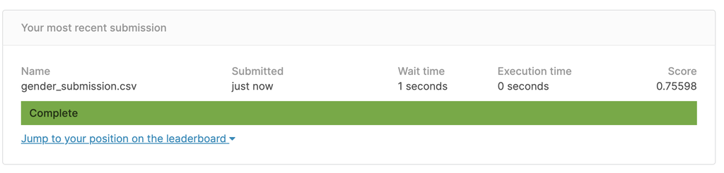

test 데이터에 대한 결과를 확인하면, 평가 지표인 accuracy가 0.756 정도 나오는 것을 볼 수 있다.

앞서 train 데이터에서는 0.807 정도의 값이 나왔던 것에 비해서는 조금 낮게 나왔던 것을 확인할 수 있다.

그렇지만 그 차이가 매우 심하지는 않아서 Overfitting 이라고 하기엔 조금 어렵지 않을까 생각된다.

또한 간단한 전처리를 수행하고, 모델을 만들어보았는데 새로운 변수들을 추가하고, 활용한다면 더 성능을 높일 수 있을 것으로 생각된다.

### 문제 4, 5번에 대한 또 다른 풀이

```r
train <- read.csv('./train.csv')
test <- read.csv('./test.csv')
summary(train)
```

```
##   PassengerId       Survived          Pclass          Name
##  Min.   :  1.0   Min.   :0.0000   Min.   :1.000   Length:891
##  1st Qu.:223.5   1st Qu.:0.0000   1st Qu.:2.000   Class :character
##  Median :446.0   Median :0.0000   Median :3.000   Mode  :character
##  Mean   :446.0   Mean   :0.3838   Mean   :2.309
##  3rd Qu.:668.5   3rd Qu.:1.0000   3rd Qu.:3.000
##  Max.   :891.0   Max.   :1.0000   Max.   :3.000
##
##      Sex                 Age            SibSp           Parch
##  Length:891         Min.   : 0.42   Min.   :0.000   Min.   :0.0000
##  Class :character   1st Qu.:20.12   1st Qu.:0.000   1st Qu.:0.0000
##  Mode  :character   Median :28.00   Median :0.000   Median :0.0000
##                     Mean   :29.70   Mean   :0.523   Mean   :0.3816
##                     3rd Qu.:38.00   3rd Qu.:1.000   3rd Qu.:0.0000
##                     Max.   :80.00   Max.   :8.000   Max.   :6.0000
##                     NA's   :177
##     Ticket               Fare           Cabin             Embarked
##  Length:891         Min.   :  0.00   Length:891         Length:891
##  Class :character   1st Qu.:  7.91   Class :character   Class :character
##  Mode  :character   Median : 14.45   Mode  :character   Mode  :character
##                     Mean   : 32.20
##                     3rd Qu.: 31.00
##                     Max.   :512.33
##
```

Train Data에 대해서 각 Column들의 type과 정보 확인. Age에 177개의 NA 데이터를 확인 할 수 있다.

```r
colSums(is.na(train))
```

```
## PassengerId    Survived      Pclass        Name         Sex         Age
##           0           0           0           0           0         177
##       SibSp       Parch      Ticket        Fare       Cabin    Embarked
##           0           0           0           0           0           0
```

```r
train %>%
    group_by(Cabin) %>%
    count %>%
    head
```

```
## # A tibble: 6 × 2
## # Groups:   Cabin [6]
##   Cabin     n
##   <chr> <int>
## 1 ""      687
## 2 "A10"     1
## 3 "A14"     1
## 4 "A16"     1
## 5 "A19"     1
## 6 "A20"     1
```

Cabin 변수 또한 ““의 빈칸 데이터가 687개인 것을 확인 할 수 있다.

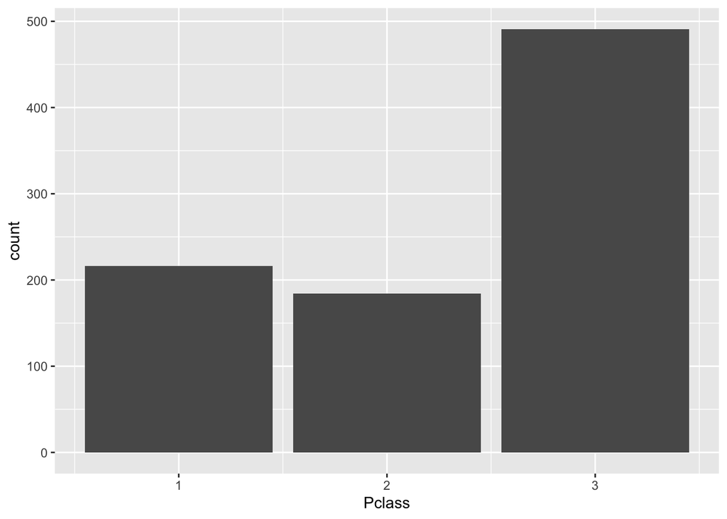

```r
train %>%
    ggplot(aes(Pclass)) +
    geom_histogram(stat = "count")
```

Pclass는 1, 2, 3 으로 분류 되는 것을 확인한다.

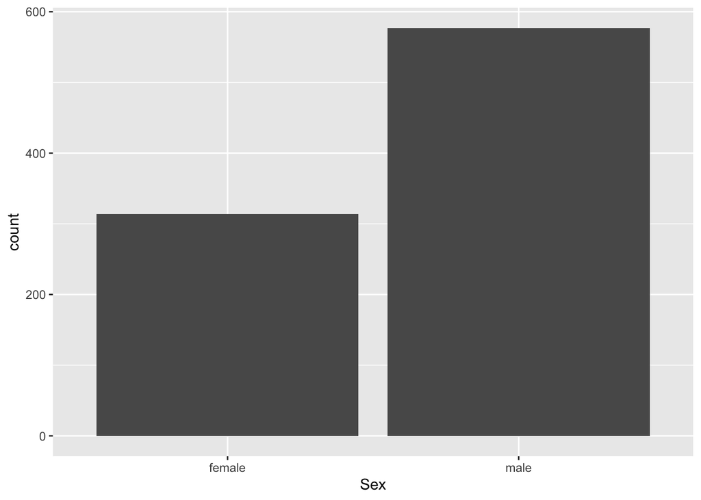

```r
train %>%
    ggplot(aes(Sex)) +
    geom_histogram(stat = "count")
```

Sex는 male, female로 나눠진다.

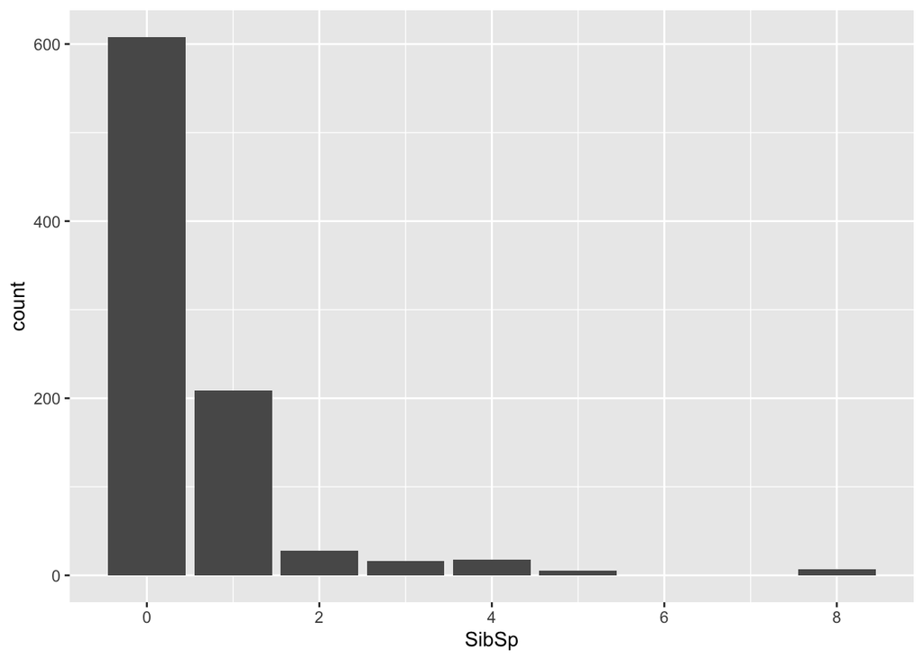

```r
train %>%
    ggplot(aes(SibSp)) +
    geom_histogram(stat = "count")
```

SibSp 는 0명에서 8명으로 나눠진다. 추후 이 데이터는 형제 자매기 있냐 없냐로만 나눌 예정이다.

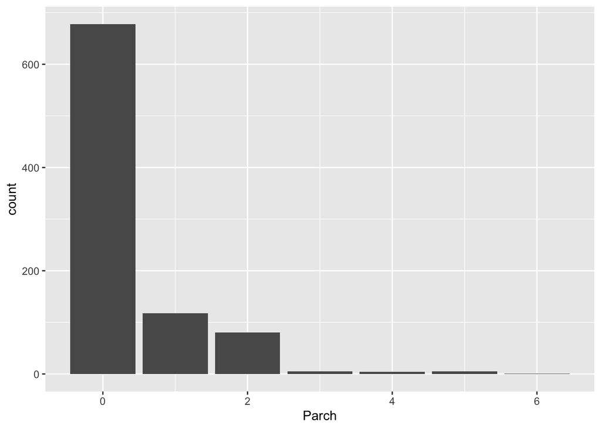

```r
train %>%
    ggplot(aes(Parch)) +
    geom_histogram(stat = "count")
```

부모/자녀 또한 0명에서 6명으로 나눠진다. 있냐 없냐로만 나눌 예정이다.

```r
summary(train$Fare)
```

```
##    Min. 1st Qu.  Median    Mean 3rd Qu.    Max.
##    0.00    7.91   14.45   32.20   31.00  512.33
```

Fare는 Quantile로 나눠줄 예정이다.

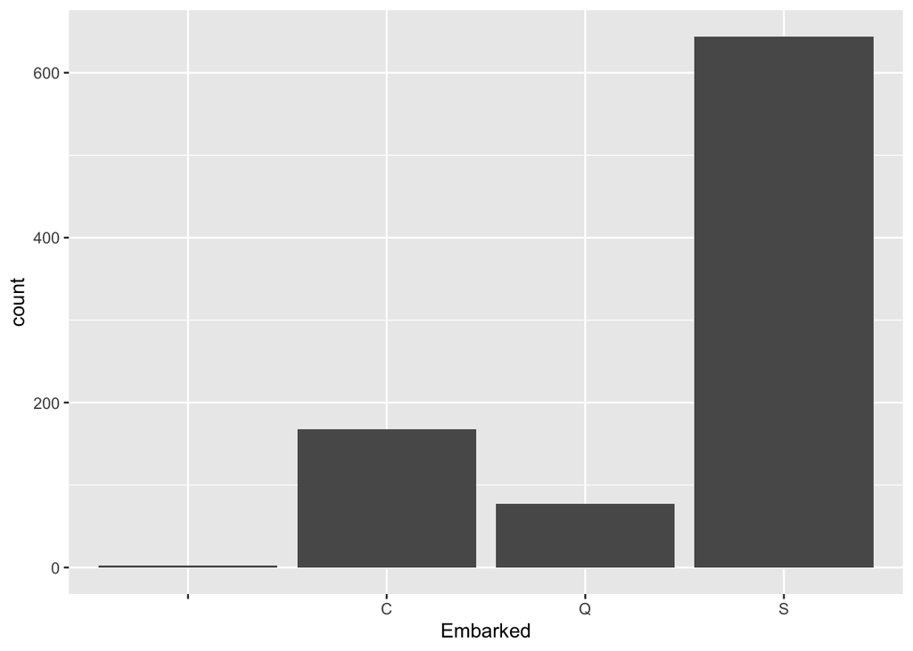

```r
train %>%
    ggplot(aes(Embarked)) +
    geom_histogram(stat = "count")
```

Embarked 는 C, Q, S와 몇개의 “” 데이터가 존재한다.

```r
train.df <- train %>%
    select(Survived, Pclass, Sex, SibSp, Parch, Fare, Embarked)
```

train.df에 Name, Age, Cabin, Ticket은 제외하고 넣어준다.

```r
q <- quantile(train$Fare)

train.df$Pclass1 <- ifelse(train.df$Pclass == 1, 1, 0)
train.df$Pclass2 <- ifelse(train.df$Pclass == 2, 1, 0)
train.df$Pclass3 <- ifelse(train.df$Pclass == 3, 1, 0)
train.df$Sex_M <- ifelse(train.df$Sex == "male", 1, 0)
train.df$Sex_F <- ifelse(train.df$Sex == "female", 1, 0)
train.df$Embarked_C <- ifelse(train.df$Embarked == 'C', 1, 0)
train.df$Embarked_Q <- ifelse(train.df$Embarked == 'Q', 1, 0)
train.df$Embarked_S <- ifelse(train.df$Embarked == 'S', 1, 0)
train.df$Fare_Verylow <- ifelse(train.df$Fare < q[2], 1, 0)
train.df$Fare_Low <- ifelse((train.df$Fare < q[3] &&
                                train.df$Fare >= q[2]), 1, 0)
train.df$Fare_High <- ifelse(train.df$Fare < q[4] &
                                train.df$Fare >= q[3], 1, 0)
train.df$Fare_Veryhigh <- ifelse(train.df$Fare <= q[5] &
                                 train.df$Fare >= q[4], 1, 0)
train.df$SibSp_None <- ifelse(train.df$SibSp == 0, 1, 0)
train.df$SibSp_Exist <- ifelse(train.df$SibSp > 0, 1, 0)
train.df$Parch_None <- ifelse(train.df$Parch == 0, 1, 0)
train.df$Parch_Exist <- ifelse(train.df$Parch > 0, 1, 0)
```

모든 변수에 대해서 dummy coding을 해주었다. Fare 같은 경우 quantile로 나눠줘서 Very low, low, high, very high로 구간을 설정 해주고 dummy variable로 만들어준다. Sib과 Parch도 있냐 없냐 2가지의 경우의 수로만 축소 해주었고 Embarked, Sex, PClass 는 주어진 변수대로 분류해주었다.

```r
train.df <- train.df %>%
    select(-c(Pclass, Sex, Fare, SibSp, Parch, Embarked, ))
```

dummy coding을 해주었으면 기존에 있던 변수들은 제거해준다.

```r
sigmoid <- function(x) {
    1 / ( 1 + exp(-x) )
}

h <- function(x, theta_vector) {
    sigmoid(theta_vector %*% x)
}
costFunction3 <- function(theta_vector) {
    hx <- apply(feature.df3, 1, function(x){h(x,theta_vector)})
    costV <- labelVector3 * log(hx) + (1-labelVector3) * log(1-hx)
    -mean(costV)
}
```

우리가 사용할 cost function과 hypothesis에 대한 function 정의를 해준다.

```r
feature.df3 <- train.df %>%
    mutate(bias = 1) %>%
    select(-Survived)
labelVector3 <- train.df$Survived

theta_vector3 <- c(0,0,0,0,0,0,0,0,0,0,0,0,0,0,0,0,0)

costFunction3(theta_vector3)
```

```
## [1] 0.6931472
```

feature.df에 bias를 넣어주고 survived만 제외한 변수들을 넣어준다. bias와 함께 변수가 17개여서 theta_vector에 17개의 초기값들을 넣어준다. labelVector 에 우리가 예측하고 싶은 Survived의 데이터를 넣어준다.

그러면 0.69의 cost Function이 나오는 것을 확인 할 수 있다.

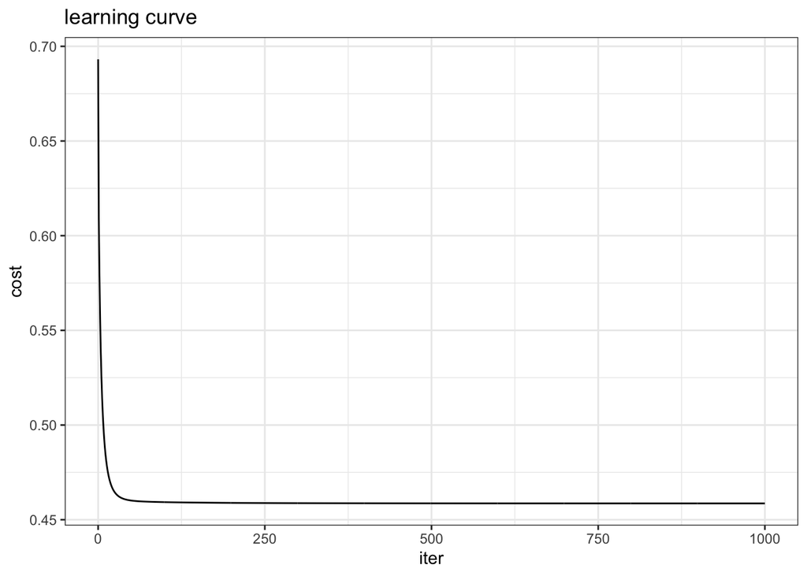

```r
costDF3 <- data.frame(iter = 0,
                      t0 = theta_vector3[1],
                      t1 = theta_vector3[2],
                      t2 = theta_vector3[3],
                      t3 = theta_vector3[4],
                      t4 = theta_vector3[5],
                      t5 = theta_vector3[6],
                      t6 = theta_vector3[7],
                      t7 = theta_vector3[8],
                      t8 = theta_vector3[9],
                      t9 = theta_vector3[10],
                      t10 = theta_vector3[11],
                      t11 = theta_vector3[12],
                      t12 = theta_vector3[13],
                      t13 = theta_vector3[14],
                      t14 = theta_vector3[15],
                      t15 = theta_vector3[16],
                      t17 = theta_vector3[17],
                      cost = costFunction3(theta_vector3))
num_iter <- 1000
m <- nrow(feature.df3)
alpha = 1
for (i in 1:num_iter) {
    theta_update3 <- (t(as.matrix(feature.df3)) %*% (apply(feature.df3, 1, function(x){h(x, theta_vector3)}) - labelVector3)) / m*alpha
    theta_vector3 <- theta_vector3 - theta_update3[,1]
    costDF3 <- rbind(costDF3, c(i, theta_vector3, costFunction3(theta_vector3)))
}

costDF3 %>%
    ggplot(aes(x = iter, y = cost)) +
    geom_line() +
    ggtitle('learning curve') +
    theme_bw()
```

logistic regression을 실행시켜준다. Cost 값이 잘 줄어드는 것을 iteration과 cost의 그래프를 그린 섟으로 확인이 가능하다.

```r
costDF3[1001,]
```

```
##      iter        t0        t1         t2        t3       t4        t5        t6
## 1001 1000 0.9732449 0.1600509 -0.9580446 -1.202185 1.377436 0.2129454 0.1583887
##              t7         t8 t9        t10        t11       t12        t13
## 1001 -0.4027001 -0.2669889  0 -0.1411478 -0.2745115 0.1074347 0.06781644
##               t14       t15       t17      cost
## 1001 -0.004863598 0.1801147 0.1752511 0.4586106
```

```r
theta_vector3
```

```
##       Pclass1       Pclass2       Pclass3         Sex_M         Sex_F
##   0.973244864   0.160050879  -0.958044642  -1.202184820   1.377435921
##    Embarked_C    Embarked_Q    Embarked_S  Fare_Verylow      Fare_Low
##   0.212945363   0.158388697  -0.402700054  -0.266988855   0.000000000
##     Fare_High Fare_Veryhigh    SibSp_None   SibSp_Exist    Parch_None
##  -0.141147772  -0.274511467   0.107434659   0.067816442  -0.004863598
##   Parch_Exist          bias
##   0.180114699   0.175251101
```

우리가 가지게 된 최종 학습된 수치이다.

```r
fin <- theta_vector3

predict <- as.data.frame(ifelse( fin[17] + fin[1]*train.df$Pclass1 +
                                             fin[2]*train.df$Pclass2 +
                                fin[3]*train.df$Pclass3 +
                                fin[4]*train.df$Sex_M + fin[5]*train.df$Sex_F +
                                fin[6]*train.df$Embarked_C +
                                fin[7] * train.df$Embarked_Q + fin[8] * train.df$Embarked_S +
                                fin[9] * train.df$Fare_Verylow + fin[10] * train.df$Fare_Low +
                                fin[11] * train.df$Fare_High +
                                fin[12] * train.df$Fare_Veryhigh + fin[13] * train.df$SibSp_None +
                                fin[14] * train.df$SibSp_Exist + fin[15] * train.df$Parch_None +
                                fin[16] * train.df$Parch_Exist > 0.5, 1, 0))
```

우리가 가진 train 데이터에다가 train을 시켜본다.

```r
prediction <- data.frame( train.df$Survived, predict)
colnames(prediction) <- c('actual', 'predict')
prediction <- prediction %>%
    mutate(correct = actual == predict)

sum(prediction$correct) / 891
```

```
## [1] 0.8114478
```

Train 데이터에 적용한 결과 81.1%의 accuracy를 보여준다.

```r
test.df <- test %>%
    select(Pclass, Sex, SibSp, Parch, Fare, Embarked)

test.df$Pclass1 <- ifelse(test.df$Pclass == 1, 1, 0)
test.df$Pclass2 <- ifelse(test.df$Pclass == 2, 1, 0)
test.df$Pclass3 <- ifelse(test.df$Pclass == 3, 1, 0)
test.df$Sex_M <- ifelse(test.df$Sex == "male", 1, 0)
test.df$Sex_F <- ifelse(test.df$Sex == "female", 1, 0)
test.df$Embarked_C <- ifelse(test.df$Embarked == 'C', 1, 0)
test.df$Embarked_Q <- ifelse(test.df$Embarked == 'Q', 1, 0)
test.df$Embarked_S <- ifelse(test.df$Embarked == 'S', 1, 0)
test.df$Fare_Verylow <- ifelse(test.df$Fare < q[2], 1, 0)
test.df$Fare_Low <- ifelse((test.df$Fare < q[3] &&
                                test.df$Fare >= q[2]), 1, 0)
test.df$Fare_High <- ifelse(test.df$Fare < q[4] &
                                test.df$Fare >= q[3], 1, 0)
test.df$Fare_Veryhigh <- ifelse(test.df$Fare <= q[5] &
                                    test.df$Fare >= q[4], 1, 0)
test.df$SibSp_None <- ifelse(test.df$SibSp == 0, 1, 0)
test.df$SibSp_Exist <- ifelse(test.df$SibSp > 0, 1, 0)
test.df$Parch_None <- ifelse(test.df$Parch == 0, 1, 0)
test.df$Parch_Exist <- ifelse(test.df$Parch > 0, 1, 0)

test.df <- test.df %>% select(-c(Embarked, Pclass, Sex, SibSp, Parch, Fare))

head(test.df)
```

```
##   Pclass1 Pclass2 Pclass3 Sex_M Sex_F Embarked_C Embarked_Q Embarked_S
## 1       0       0       1     1     0          0          1          0
## 2       0       0       1     0     1          0          0          1
## 3       0       1       0     1     0          0          1          0
## 4       0       0       1     1     0          0          0          1
## 5       0       0       1     0     1          0          0          1
## 6       0       0       1     1     0          0          0          1
##   Fare_Verylow Fare_Low Fare_High Fare_Veryhigh SibSp_None SibSp_Exist
## 1            1        0         0             0          1           0
## 2            1        0         0             0          0           1
## 3            0        0         0             0          1           0
## 4            0        0         0             0          1           0
## 5            0        0         0             0          0           1
## 6            0        0         0             0          1           0
##   Parch_None Parch_Exist
## 1          1           0
## 2          1           0
## 3          1           0
## 4          1           0
## 5          0           1
## 6          1           0
```

test 파일을 불러와서 train에 학습된 알고리즘을 적용 시켜볼 예정이다. 그러기 위해서 train데이터와 같은 형식으로 맞춰준다.

```r
test.df$Survived <- ifelse( fin[17] + fin[1]*test.df$Pclass1 + fin[2]*test.df$Pclass2 +
                                 fin[3]*test.df$Pclass3 +
                                fin[4]*test.df$Sex_M + fin[5]*test.df$Sex_F +
                             fin[6]*test.df$Embarked_C +
                                fin[7] * test.df$Embarked_Q + fin[8] * test.df$Embarked_S +
                                 fin[9] * test.df$Fare_Verylow + fin[10] * test.df$Fare_Low +
                                 fin[11] * test.df$Fare_High +
                                fin[12] * test.df$Fare_Veryhigh + fin[13] * test.df$SibSp_None +
                                fin[14] * test.df$SibSp_Exist + fin[15] * test.df$Parch_None +
                                fin[16] * test.df$Parch_Exist > 0.5, 1, 0)
```

test.df$Survived에다가 예측 모델을 넣어주고, 데이터 형식에 맞춰서 제출하여 결과를 확인한다.

Kaggle에서 확인한 최종 결과는 약 77.511% 의 Accuracy를 가진다.

OverFitting에 조금 가까운 것 같지만 그렇게 81%와 그렇게 큰 차이는 없다고 판단된다. 지금은 OverFitting의 문제를 해결하기 보다 Bias를 어떻게 줄여서 더 좋은 학습 Model로 만들어줄지를 고민하고 시도 해봐야 된다고 생각한다.

특히 데이터 전처리 과정에서 Dummy Coding으로 진행을 하였기 때문에 Model이 복잡해져서 OverFitting이 될 걱정은 없었다. 하지만 Age와 Name에서 Title과 같은 변수들을 못 뽑아 냈기 때문에 Bias가 낮을 수 밖에 없을 것 같다. 그래서 전체적으로 Train 과 Test에서의 성능을 더 높일 수 있지 않을까 싶다.